# Evictions in the USA

Izzy Youngs

5/18/2021

Word count: 3007

# Introduction

# Problem Statement and Background

Eviction is a devastating outcome at every scale. Evicted families tend to filter down to more undesirable and dangerous neighborhoods due to the short time frames people have to secure new housing (Desmond and Shollenberger 2015), and the mark of an eviction on a tenant’s record can make it more difficult to find housing (Desmond 2012). Because of this, eviction is a significant predictor of homelessness (Collinson and Reed 2018; Crane and Warnes 2000) and results in serious negative health and education outcomes (Richter et al. 2021; Himmelstein and Desmond 2021). Despite the abundance of data on the adverse outcomes of eviction, the policies and structures contributing to eviction are difficult to study and measure. Rising housing costs, income inequality, and lack of government housing programs are often cited as factors influencing eviction, but each of these has myriad preventative policy approaches, complicating efforts to mitigate eviction (Desmond 2015). A few of the confounding factors in researching eviction causes and prevention include:

- Geographic and regional differences in economies, policy levers, and histories
- Housing markets rarely align with administrative and political boundaries
- Data are often disparate, local, lack provenance metadata, and/or have temporal misalignment
- Effective but rare policies may be difficult to extrapolate
- Policy and economic interactions can mask another policy’s individual effects

Despite these challenges, there have been attempts to study policy impacts on eviction, including supply-side development policies (Been, Ellen, and O’Regan 2019; B. J. Asquith, Mast, and Reed 2019; Mast 2019; Nathanson 2019; Damiano and Frenier 2020; Zuk and Chapple 2016), rent control (Diamond, McQuade, and Qian 2019; Pastor, Carter, and Abood 2018; B. Asquith 2019), and tenants’ right to counsel (Fracassa 2020; School 2014; “NYC Right to Counsel: First Year Results and Potential for Expansion” 2019), but most housing policy studies are not comprehensive or comparative across various regions, making generalization nearly impossible. Additionally, there are many policies which are enacted at the local level, which are much harder to measure across regions since this is not collected from federal administrative data. For example, there has been limited research around how inclusionary zoning, accessory dwelling units, affordable housing trust funds, affordable housing linkage fees, and land use policies affect eviction rates downstream.

This project will explore which policies and factors are strongest in generating predictions of eviction filing rates for jurisdictions. By understanding these factors and policies, policymakers can advocate more explicitly for legislation or programs which support the goals of resident stability across regions and governance structures.

# Data

## Outcome Variable

Data on evictions were obtained from [The Eviction Lab](https://data-downloads.evictionlab.org/), a team of researchers at Princeton University which has scraped, bought, and aggregated various data on evictions from 2000-2016 (Desmond et al. 2018). The Eviction Lab takes the total number of eviction judgements and eviction filings per geography and divides it by the Census Bureau’s estimates of the total number of occupied rental units in the same area. The share of evictions or eviction filings per jurisdiction is the eviction rate and eviction filing rate, respectively. This data is validated by the research team at Princeton; however, data quality issues remain. Local courts can vary dramatically in eviction record keeping, leading to errors even within a state (Porton, Gromis, and Desmond 2020). In addition, this data was originally created for legal purposes and not research purposes, creating challenges when linking across data and resolving discrepancies. Eviction judgement data are missing for almost 25 percent of the counties in the dataset. Many of these missing counties were also spatially clustered. According to The Eviction Lab, four states - Alaska, Arkansas, South Dakota, and North Dakota - did not have consistent data coverage to include them in the dataset for eviction rates. However, The Eviction Lab was able to obtain *filing* rates for over 86% of counties and 84% of places, so the filing rates were used for this analysis.

The unit of analysis for this report is local jurisdictions (cities and counties) and the outcome variable is the eviction filing rate from 2016. Eviction filing rates are right skewed with a strong kurtosis around a mean of 3.02. Since the distribution around the mean is extremely thin, predictive performance may suffer using regression models. In order to account for this, the filing rates were feature engineered into a categorical variable depending on whether it was above or below the mean eviction filing rate of 3.02.

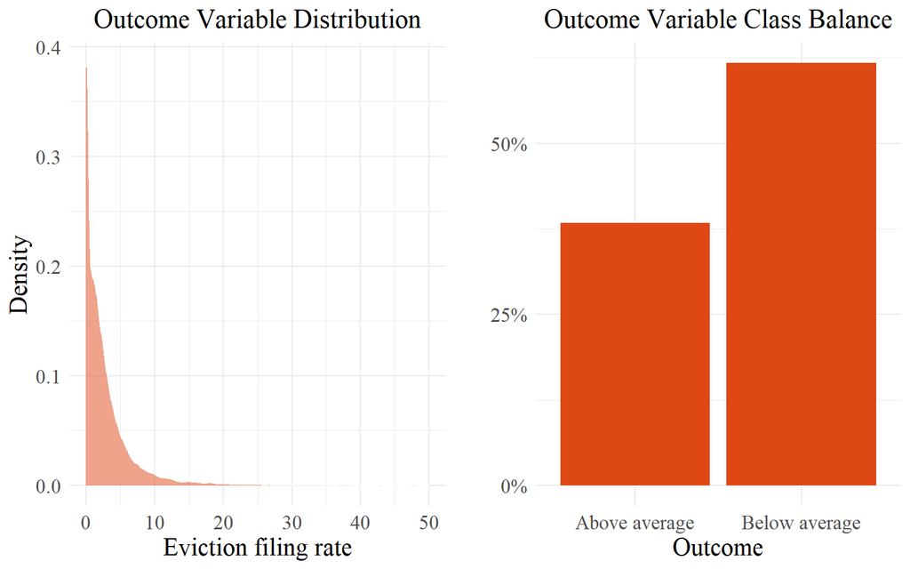

Fig. 1: Eviction filing rate distribution graphs

There is a class imbalance in the new categorical variable, with more instances of below average eviction filing rates in total, but a concentration of above average eviction filing rates along the eastern coast of the United States.

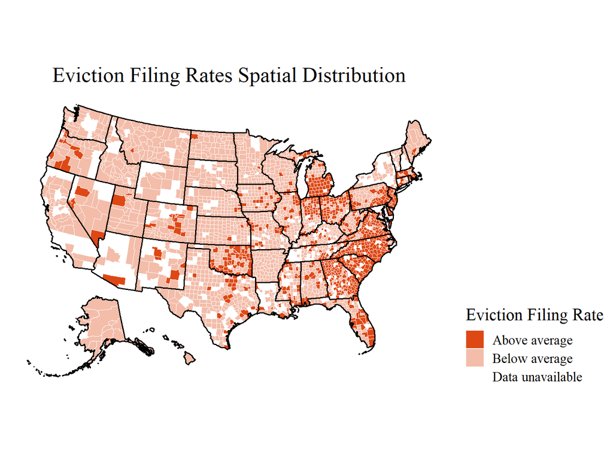

Fig. 2: Map of eviction filing rates by county across the United States

## Predictor Variables

A review of the academic literature highlighted the role of housing markets (Pastor, Carter, and Abood 2018; B. J. Asquith, Mast, and Reed 2019), tenant protection laws (“Effect of ‘Just Cause’ Eviction Ordinances on Eviction in Four California Cities” 2019; “NYC Right to Counsel: First Year Results and Potential for Expansion” 2019; Jeon, Cash, and Wilson 2019), and poverty (Lundberg and Donnelly 2019; Desmond 2012) in exacerbating eviction. Attributes in these domains, such as a jurisdiction’s land use policies, rent control laws, or income inequality, may begin to delineate between high- and low-eviction areas.

The US Census Bureau generates estimates of geographic attributes such as median household income, median rent, and general demographic patterns. The data used for this analysis are the 2015-2019 American Community Survey (ACS) estimates (Manson et al. 2017). Additional attribute data such as the minimum wage, housing voucher utilization, and building permit information was obtained from federal statistical agencies, such as the Department of Labor and the Department of Housing and Urban Development. The [Federal Research Economic Data Portal](https://fred.stlouisfed.org/series/RACEDISPARITY024510) utilizes census data to generate a dissimilarity index, a measurement of the racial segregation of a county. [MIT’s Election Lab](https://dataverse.harvard.edu/dataset.xhtml?persistentId=doi:10.7910/DVN/VOQCHQ) tracks county-level voter data, which was used to measure the overall political swing of a county. The [Centers for Disease Control](https://www.atsdr.cdc.gov/placeandhealth/svi/data_documentation_download.html) creates an index of social vulnerability to help public health officials identify at-risk populations during disasters.

There are few federal databases tracking public policies across the United States. Land use regulations and policies were obtained from the [Wharton Land Use Index](http://real-faculty.wharton.upenn.edu/gyourko/land-use-survey/) and the [National Longitudinal Land Use Survey (NLLUS)](https://datacatalog.urban.org/dataset/national-longitudinal-land-use-survey-nllus). These datasets are more sparse than the attribute information collected from federal agencies since they are relying on survey methodology for a representative sample of jurisdictions. The state’s average lot size was obtained from [Realtor.com](https://www.inman.com/2011/10/27/10-states-with-biggest-houses/), and state rental laws were collected from [Nolo](https://www.nolo.com/), [Apartments.com](https://www.apartments.com/rental-manager/resources/state-laws), and [Avail.co](http://avail.co/). Governance data (e.g. whether a county had Home Rule or not) was obtained from the [National Association of Counties](https://ce.naco.org/?dset=Government%20Structure&ind=County%20Authority) and rent control data was added from the [National Multifamily Housing Council](https://www.nmhc.org/globalassets/advocacy/rent-control/rent-control-by-state-law_2020.pdf) overview. Descriptions of each outcome variable are in Table 1.

| Variable | Type | Description | Data source |
| --- | --- | --- | --- |
| approval_delay | Continuous | Measure of permit approval delay | Wharton Land Use Index |
| car_dominant | Continuous | Share of population that drives | Census Bureau |
| court_involvement | Continuous | Amount of court involvement in land use decisions | Wharton Land Use Index |
| d_adus | Categorical | Jurisdiction allows ADUs | National Longitudinal Land Use Survey |
| d_afh_growth_bonus | Categorical | Jurisdiction makes a growth control exemption for affordable housing | National Longitudinal Land Use Survey |
| d_afh_req | Categorical | Jurisdiction requires affordable housing from private development | Wharton Land Use Index and NLLUS |
| d_ahtf | Categorical | Affordable housing trust fund | National Longitudinal Land Use Survey |
| d_allows_late_payment | Categorical | State allows late payment | Avail.co |
| d_any_incentives | Categorical | Any incentives for affordable housing | National Longitudinal Land Use Survey |
| d_density_bonus | Categorical | Density bonuses for affordable housing | National Longitudinal Land Use Survey |
| d_far_bonus | Categorical | Minimum dwelling unit size exemption for affordable housing | National Longitudinal Land Use Survey |
| d_growth_boundary | Categorical | Growth boundary | National Longitudinal Land Use Survey |
| d_growth_control | Categorical | Locale restricts residential growth | National Longitudinal Land Use Survey |
| d_homerule | Categorical | Does the county have home rule | NaCO |
| d_if_deposit_limit | Categorical | If there is a limit on the deposit that can be charged | Avail.co |
| d_impact_fee_waivers | Categorical | Impact fee waivers for affordable housing | National Longitudinal Land Use Survey |
| d_impact_fees | Categorical | Whether a developer has to pay impact fees | Wharton Land Use Index and NNLUS |
| d_is_county | Categorical | Feature engineered: Whether the jurisdiction is a county or not (a place) | Census Bureau |
| d_limits_on_late_fees | Categorical | Are there limits on the amount one can charge in late fees | Avail.co |
| d_linkage_fees | Categorical | Linkage fees for affordable housing | National Longitudinal Land Use Survey |
| d_moratorium | Categorical | Housing moratorium | National Longitudinal Land Use Survey |
| d_notice_before_entry | Categorical | Are there laws requiring a notice before entry | Avail.co |
| d_open_space | Categorical | Whether the area mandates open space set asides from developers | Wharton Land Use Index |
| d_permit_incentive | Categorical | Fast-track permit incentives for affordable housing | National Longitudinal Land Use Survey |
| d_permits_mobile | Categorical | Permits mobile homes | National Longitudinal Land Use Survey |
| d_permits_tinyhome | Categorical | Permits tiny homes | National Longitudinal Land Use Survey |
| d_receipts_required | Categorical | Whether receipts are required for the payment of rent | Avail.co |
| d_rental_license_required | Categorical | Do landlords need a rental license | Avail.co |
| d_specific_rent_control | Categorical | Does the locale have rent control | National Multifamily Housing Council |
| d_statewide_rent_control | Categorical | Does the state allow rent control | National Multifamily Housing Council |

[output cut: 54 more lines]

Table 1: Predictor variable descriptions and sources

Several predictor variable values were sparsely available. If over 70 percent of a variable’s values were missing, that variable was coded as sparse. If the observation contained a value for a sparse variable, the observation was kept. This left a data frame of almost 6,000 observations, which were joined to each other and the eviction filing rates through census geographic identifiers.

The overall missingness of the data was slightly over 28 percent across 83 variables. Most of the missingness was concentrated in the geographies with below average eviction filing rates.

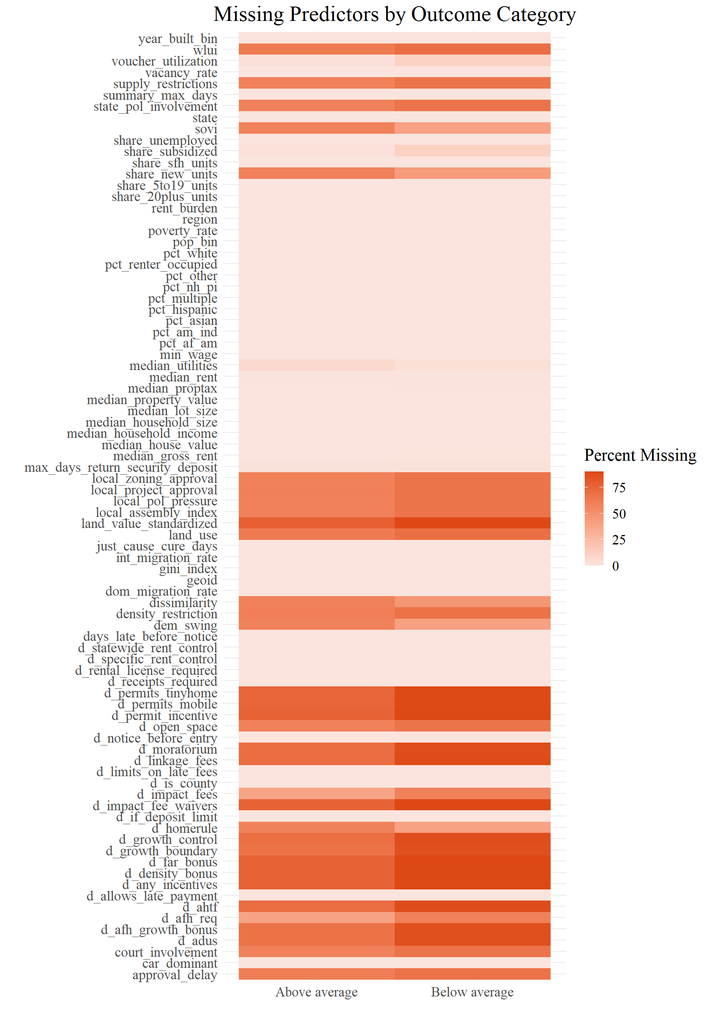

Fig. 3: Missingness chart of all predictor variables by eviction filing rate

There is some skew in several predictors and some outliers, but overall the distribution of the predictor variables was not unusual.

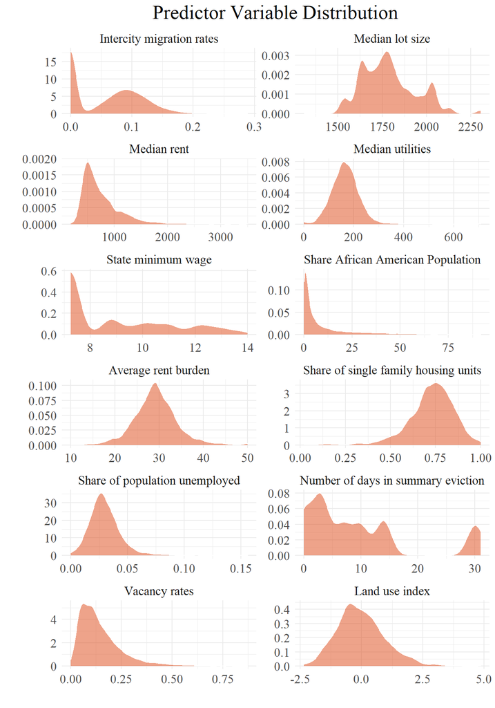

Fig. 4: Density distribution plots for a selection of continuous predictor variables

The categorical predictor variables were mostly balanced, although most states do not permit tenants to pay their rent within a grace period before a landlord may file an eviction or require a license to manage rental properties, which could impact how important these variables are to the model. Additionally, rent control is exceedingly rare, so the imbalance was particularly extreme for that variable.

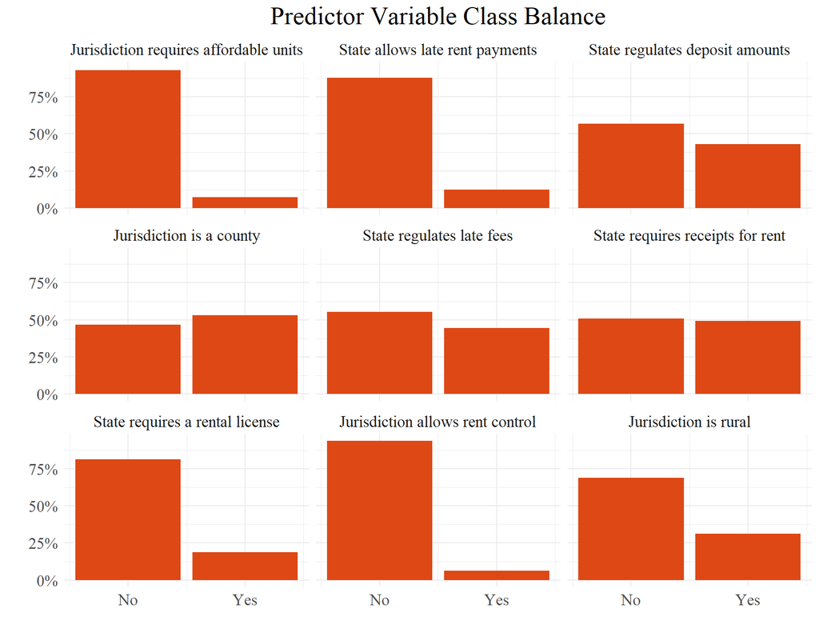

Fig. 5: Class balance bar graphs for a selection of categorical predictor variables

# Analysis

## Splitting

There were nearly 6,000 observations in the data set, but if all of the data were used to train the models, the models could learn the noise *and* the signal and overfit the predictions, performing poorly on new data. The models need to be tested against data that has been set aside for testing purposes. This test data should not be analyzed at all, so the data frame needed to be split. For this analysis, the data was split into three data frames:

- A training data set (~70%)
- A validation data set (~10%)
- A test data set (~20%)

This method of splitting the data three times allows for iteratively ensuring that the model is not overfitting the data by testing models against the validation set instead of the test data set without compromising the integrity of the scientific process. The outcome variable (eviction filing rates) remained equally represented in each split data set through stratification.

## Preprocessing

The data was then preprocessed for analysis in a few ways. Then missing values were imputed utilizing K-nearest neighbors imputation for both the categorical and continuous variables. To ensure variables were being analyzed within the same feature space, numeric standardization methods were explored, including YeoJohnson, normalization, and range standardization, but logging the variables performed best to reduce the impact of outliers.

## Cross-validation

In order to test the machine learning models, a few cross-validation techniques were applied. Once the training data was created, another method for cross-validating our model performance was needed. Re-sampling from the training data and refitting the models on each sample generates estimates for the test or validation error. For this analysis, the training data was further split into $k = 5$ sample “folds”.

## Model testing

Several supervised machine learning models were tested in an attempt to identify the best fitting classification prediction model. The performance of each classification model was compared using the area under the ROC curve, a measurement of the true positive rate (sensitivity or recall) and false positive rate (specificity) of a model. Eviction is a pernicious phenomenon with enormous ramifications, so for this analysis it is far more important to be accurate in predicting where eviction rates are high than accurately predicting where they are low. Therefore, the ROC measures for each model were compared with special attention to the specificity/sensitivity tradeoff, where higher specificity metrics were preferred.

# Results

## Model Performance

Several models were compared, including: CART, logit, Random Forest, K-nearest neighbors, Support Vector Machines, and AdaBoost. After running each model, the Random Forest model performed slightly better than the other models across both ROC and specificity metrics.

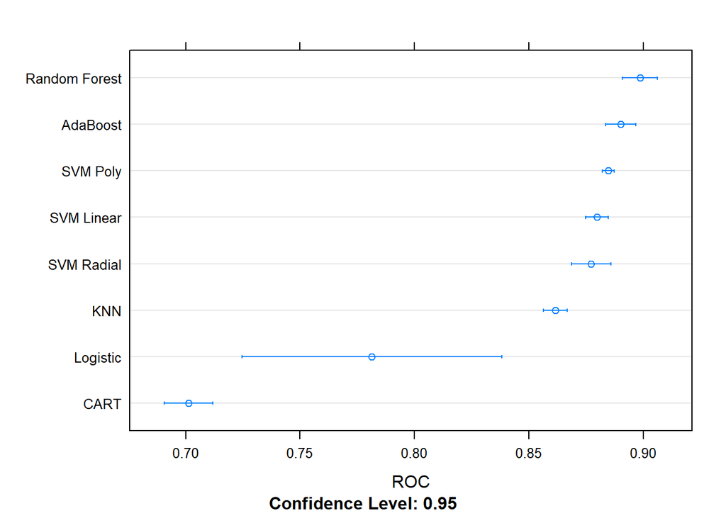

Fig. 6: Machine learning model ROC performance

With an ROC of .89, this model is considered excellent (Hosmer Jr, Lemeshow, and Sturdivant 2013). The specificity of the model is also high at .84. This model was highly accurate in its’ predictions of which jurisdictions had above-average eviction rates in 2016. The model was then applied to the validation data and had an ROC of .93 and a specificity of .86, making it an outstanding model.

## Variable Importance

Random Forest models aggregate many decision trees together, generating a more robust model than any single CART model, but compromising the interpretability of the model. To assess which variables were most important in the Random Forest predictions, a variable importance method called “permutation importance” was utilized. By scrambling the data one variable at a time, the permutation importance method tests if the predictive performance of the model decreases. If it does, the variable is considered highly important to the model performance. For this model, the most important variables were:

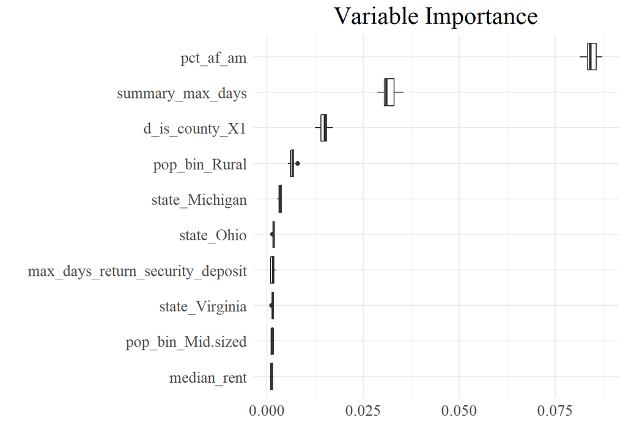

Fig. 7: Variable importance plot

A few variables stood out. First, a few states were strong predictors of the eviction filing rates for their respective jurisdictions. Additionally, whether the jurisdiction was a county or a city was also important for the Random Forest model. However, despite these variables being important, it is unclear the direction of importance. For example, how does the share of African Americans in a jurisdiction impact the model’s predictive outcome? Using partial dependence plots, the direction of the variables’ importance was assessed.

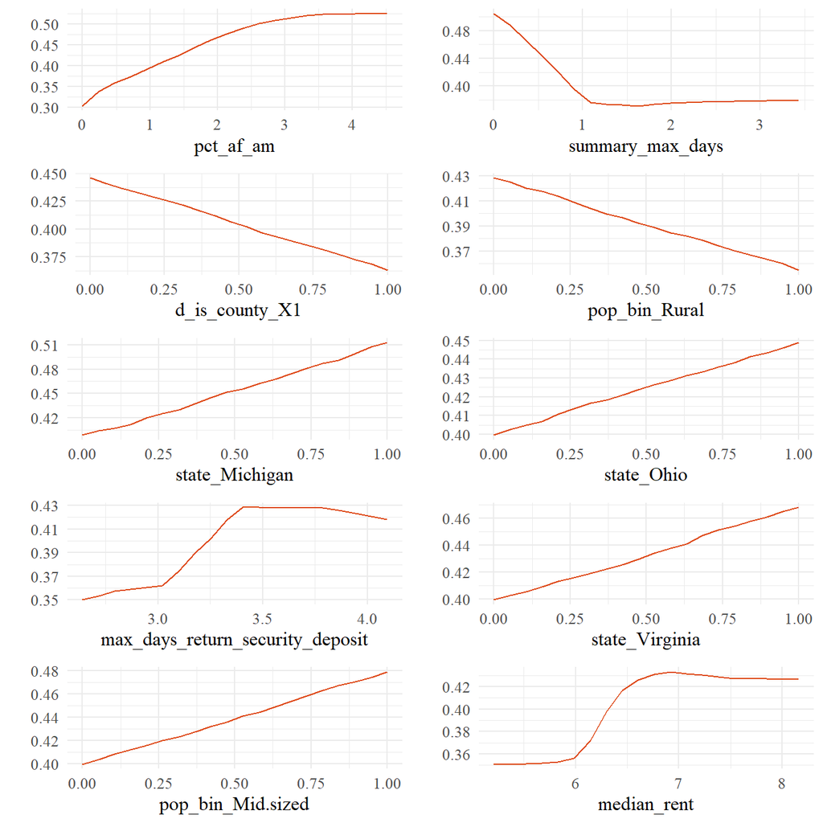

Fig. 8: Partial dependence plots from top 10 variables

## Global Surrogate Model

Since Random Forest models are inherently less interpretable, using the predicted outcomes in a CART model may provide a more interpretable surrogate model. However, this model explains only 43 percent of the variation of the response data around its mean ($R^2 = .43$). This model does not do an outstanding job predicting whether a jurisdiction will have a high or low eviction filing rate, and it illustrates how complex predicting eviction filing rates is. Despite its overall weakness, the major cut points in the model are similar to the top ten important variables for the Random Forest model:

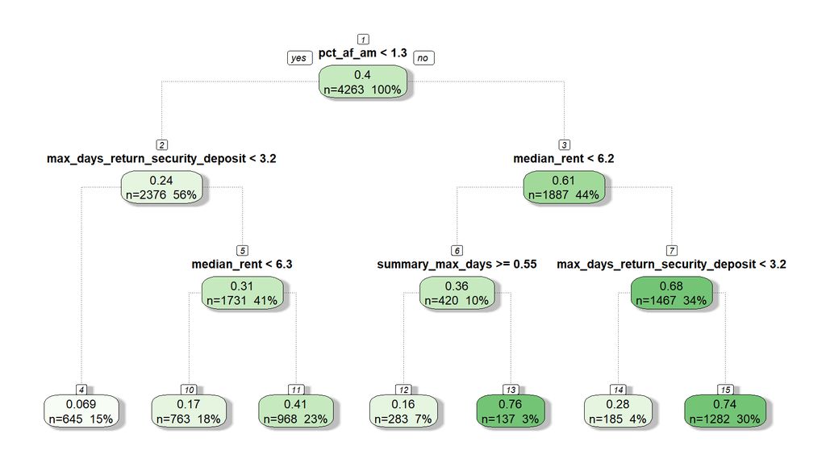

Fig. 9: Decision tree from global surrogate model

According to the surrogate model, if the jurisdiction had a high share of African Americans, the median rent was high, the summary eviction process was short, or the landlord had many days to return a tenant’s security deposit, the eviction filing rates were predicted to be above average.

# Discussion

The results of this analysis, like most data science, points to a need for additional data and tests. Eviction filing rates are not even perfectly reflective of actual eviction judgments. Eviction filing rates may be higher in some jurisdictions due to policy choices; for example, the cost to file an eviction notice in one state or court may be much less than in another—data which was not collected but could have a significant impact on the decision to file an eviction (Nelson et al. 2021). Given these findings, it is not possible to say these are all of the factors which contribute to eviction.

Despite these challenges, there is a great deal of interesting and policy-relevant information here. The model found that there is a significant role that race plays in determining eviction rates. Race and eviction are often collinear with other indicators of disadvantage, such as poverty or segregation, but none of these variables were as important to eviction as race. Tenant protections around race, including increased efforts to identify and weed out racism in private rental markets, may be a critical component of reducing eviction.

Additionally, the model predicted that providing longer eviction processes to tenants would improve the eviction rates. There are myriad potential reasons for this, including offering more time for tenants to cure any late payments or incentivizing landlords to work with tenants on late rent instead of evicting. The model pointed out that a handful of states also have very high overall eviction filing rates, a sign that those states’ legislation on tenant protections and eviction should be scrutinized.

A few of the predictor variables also pointed to housing market issues. Rural counties generally experience less housing demand and a cheaper overall costs of living than urban centers with strong housing markets as seen by higher median rents. Together, these indicate that a combination of short-term tenant protection policies and longer-term housing market approaches to bring down the cost of housing could alleviate the eviction rates larger jurisdictions with higher housing demand. In urban metros, a variety of policies may be needed to bring down overall eviction filing rates, including fair housing policies and housing market policies, whereas for smaller or more rural centers, tenant protections may be the best policy solution to bringing down eviction rates.

Future analyses could include identifying jurisdictions where there were false positives or false negatives and exploring the demographic, housing market, economic conditions, and policies which could have been a factor. Local policies such as the Right of First Refusal and guaranteed tenant counsel (Mironova 2019) are incredibly uncommon, but could show promising effects on eviction rates. There are potentially thousands of policies which could impact eviction rates, including policies protecting domestic violence victims and families with children, Medicaid expansion (Zewde et al. 2019), minimum wage increases, and local housing voucher programs.

Some state and local policy data on Medicaid expansion, tenant legal counsel, and Right of First Refusal policies are located on websites and in documentation through local websites, but aggregating this information on a national level could be incredibly challenging. Focusing on a representative sample of states with a diversity of policies, jurisdictional types, and demographics, such as New York or California, could potentially be generalized to the rest of the population.

Altogether, the analysis resulted in a strong but difficult-to-interpret model for predicting eviction filing rates. Unfortunately, the goal of the analysis was to develop an interpretable model, but these preliminary results are interesting, and continued development of the model may result in a more interpretable model in the coming months as the analysis iterates over new variables and geographic scales. Ultimately, this model accurately identified which jurisdictions had high and low eviction filing rates based on the factors and policies provided, which is a success.

# References

Arnold, Jeffrey B. 2021. *Ggthemes: Extra Themes, Scales and Geoms for ’Ggplot2’*. [https://CRAN.R-project.org/package=ggthemes](https://cran.r-project.org/package=ggthemes).

Asquith, Brian. 2019. “Do Rent Increases Reduce the Housing Supply Under Rent Control? Evidence from Evictions in San Francisco.” SSRN Scholarly Paper ID 3165599. Rochester, NY: Social Science Research Network. https://doi.org/10.2139/ssrn.3165599.

Asquith, Brian J, Evan Mast, and Davin Reed. 2019. “Supply Shock Versus Demand Shock: The Local Effects of New Housing in Low-Income Areas.” https://doi.org/10.17848/wp19-316.

Auguie, Baptiste. 2017. *GridExtra: Miscellaneous Functions for "Grid" Graphics*. [https://CRAN.R-project.org/package=gridExtra](https://cran.r-project.org/package=gridExtra).

Been, Vicki, Ingrid Gould Ellen, and Katherine O’Regan. 2019. “Supply Skepticism: Housing Supply and Affordability.” *Housing Policy Debate* 29 (1): 25–40. https://doi.org/10.1080/10511482.2018.1476899.

Collinson, Robert, and Davin Reed. 2018. “The Effects of Evictions on Low-Income Households,” 82.

Corporation, Microsoft, and Steve Weston. 2020. *DoParallel: Foreach Parallel Adaptor for the ’Parallel’ Package*. [https://CRAN.R-project.org/package=doParallel](https://cran.r-project.org/package=doParallel).

Crane, Maureen, and Anthony M. Warnes. 2000. “Evictions and Prolonged Homelessness.” *Housing Studies* 15 (5): 757–73. https://doi.org/10.1080/02673030050134592.

Damiano, Anthony, and Chris Frenier. 2020. “Build Baby Build?: Housing Submarkets and the Effects of New Construction on Existing Rents,” 48.

Data, MIT Election, and Science Lab. 2018. “County Presidential Election Returns 2000-2016.” Harvard Dataverse. https://doi.org/10.7910/DVN/VOQCHQ.

Desmond, Matthew. 2015. “Unaffordable America: Poverty, Housing, and Eviction,” no. 22: 6.

———. 2012. “Eviction and the Reproduction of Urban Poverty.” *American Journal of Sociology* 118 (1): 88–133. https://doi.org/10.1086/666082.

Desmond, Matthew, Ashley Gromis, Lavar Edmonds, James Hendrickson, Katie Krywokulski, Lillian Leung, and Adam Porton. 2018. “Eviction Lab Methodology Report.” Version.

Desmond, Matthew, and Tracey Shollenberger. 2015. “Forced Displacement from Rental Housing: Prevalence and Neighborhood Consequences.” *Demography* 52 (5): 1751–72. http://www.jstor.org/stable/43697545.

Diamond, Rebecca, Tim McQuade, and Franklin Qian. 2019. “The Effects of Rent Control Expansion on Tenants, Landlords, and Inequality: Evidence from San Francisco.” *American Economic Review* 109 (9): 3365–94. https://doi.org/10.1257/aer.20181289.

Echenique, Federico, and Roland G Fryer Jr. 2007. “A Measure of Segregation Based on Social Interactions.” *The Quarterly Journal of Economics* 122 (2): 441–85.

“Effect of ‘Just Cause’ Eviction Ordinances on Eviction in Four California Cities.” 2019. Journal of Public and International Affairs. 2019. https://jpia.princeton.edu/news/effect-just-cause-eviction-ordinances-eviction-four-california-cities.

Flanagan, Barry E, Edward W Gregory, Elaine J Hallisey, Janet L Heitgerd, and Brian Lewis. 2011. “A Social Vulnerability Index for Disaster Management.” *Journal of Homeland Security and Emergency Management* 8 (1).

Fracassa, Dominic. 2020. “San Francisco’s New Eviction-Prevention Program Is Working, but Is It Enough?” San Francisco Chronicle. February 25, 2020. https://www.sfchronicle.com/bayarea/article/San-Francisco-s-new-eviction-prevention-program-15081197.php.

Greenwell, Brandon M. 2017. “Pdp: An R Package for Constructing Partial Dependence Plots.” *The R Journal* 9 (1): 421–36. https://journal.r-project.org/archive/2017/RJ-2017-016/index.html.

Greenwell, Brandon M., and Bradley C. Boehmke. 2020. “Variable Importance Plots—an Introduction to the Vip Package.” *The R Journal* 12 (1): 343–66. https://doi.org/10.32614/RJ-2020-013.

Gyourko, Joseph, Jonathan S Hartley, and Jacob Krimmel. 2021. “The Local Residential Land Use Regulatory Environment Across Us Housing Markets: Evidence from a New Wharton Index.” *Journal of Urban Economics* 124: 103337.

Himmelstein, Gracie, and Matthew Desmond. 2021. “Association of Eviction with Adverse Birth Outcomes Among Women in Georgia, 2000 to 2016.” *JAMA Pediatrics*, March. https://doi.org/10.1001/jamapediatrics.2020.6550.

Hosmer Jr, David W, Stanley Lemeshow, and Rodney X Sturdivant. 2013. *Applied Logistic Regression*. Vol. 398. John Wiley & Sons.

Jeon, Jae Sik, Anna Cash, and Katie Wilson. 2019. “Exploring the Effectiveness of Tenant Protections in Silicon Valley,” 9.

Kuhn, Max. 2020. *Caret: Classification and Regression Training*. [https://CRAN.R-project.org/package=caret](https://cran.r-project.org/package=caret).

Kuhn, Max, and Davis Vaughan. 2021. *Yardstick: Tidy Characterizations of Model Performance*. [https://CRAN.R-project.org/package=yardstick](https://cran.r-project.org/package=yardstick).

Kuhn, Max, and Hadley Wickham. 2020. *Recipes: Preprocessing Tools to Create Design Matrices*. [https://CRAN.R-project.org/package=recipes](https://cran.r-project.org/package=recipes).

Lo, Lydia, Megan Gallagher, Rolf Pendall, Ananya Hariharan, and Christopher Davis. 2019. “National Longitudinal Land Use Survey.” *The Urban Institute: Washington, DC Accessible from: Data Developed at the Urban Institute, and Made Available Under the ODC-BY* 1. https://datacatalog.urban.org/dataset/national-longitudinal-land-use-sur.

Lundberg, Ian, and Louis Donnelly. 2019. “A Research Note on the Prevalence of Housing Eviction Among Children Born in U.S. Cities.” *Demography* 56 (1): 391–404. https://doi.org/http://dx.doi.org.proxy.library.georgetown.edu/10.1007/s13524-018-0735-y.

Manson, Steven, Jonathan Schroeder, David Van Riper, Steven Ruggles, and others. 2017. “Ipums National Historical Geographic Information System: Version 12.0 [Database].” *Minneapolis: University of Minnesota* 39.

Mast, Evan. 2019. “The Effect of New Market-Rate Housing Construction on the Low-Income Housing Market.” W.E. Upjohn Institute. https://doi.org/10.17848/wp19-307.

Mironova, Oksana. 2019. “Rent Regulation in New York City.”

Müller, Kirill. 2020. *Here: A Simpler Way to Find Your Files*. [https://CRAN.R-project.org/package=here](https://cran.r-project.org/package=here).

Nathanson, Charles G. 2019. “Trickle-down Housing Economics,” 56.

Nelson, Kyle, Philip Garboden, Brian J McCabe, and Eva Rosen. 2021. “Evictions: The Comparative Analysis Problem.” *Housing Policy Debate*, 1–21.

“NYC Right to Counsel: First Year Results and Potential for Expansion.” 2019. 2019. https://www.cssny.org/news/entry/nyc-right-to-counsel.

Pastor, Manuel, Vanessa Carter, and Maya Abood. 2018. “Rent Matters: What Are the Impacts of Rent Stabilization Measures?” 31.

Porton, Adam, Ashley Gromis, and Matthew Desmond. 2020. “Inaccuracies in Eviction Records: Implications for Renters and Researchers.” *Housing Policy Debate*, July, 1–18. https://doi.org/10.1080/10511482.2020.1748084.

R Core Team. 2020. *R: A Language and Environment for Statistical Computing*. Vienna, Austria: R Foundation for Statistical Computing. [https://www.R-project.org/](https://www.r-project.org/).

Richter, Francisca García-Cobián, Claudia Coulton, April Urban, and Stephen Steh. 2021. “An Integrated Data System Lens into Evictions and Their Effects.” *Housing Policy Debate*, March, 1–23. https://doi.org/10.1080/10511482.2021.1879201.

Rudis, Bob. 2020. *Albersusa: Tools, Shapefiles & Data to Work with an ’Albersusa’ Composite Projection*. https://github.com/hrbrmstr/albersusa.

School, Stanford Law. 2014. “San Francisco Right to Civil Counsel Pilot Program Documentation Report.” Stanford Law School. 2014. https://law.stanford.edu/publications/san-francisco-right-to-civil-counsel-pilot-program-documentation-report/.

Silge, Julia, Fanny Chow, Max Kuhn, and Hadley Wickham. 2021. *Rsample: General Resampling Infrastructure*. [https://CRAN.R-project.org/package=rsample](https://cran.r-project.org/package=rsample).

Tierney, Nicholas, Di Cook, Miles McBain, and Colin Fay. 2020. *Naniar: Data Structures, Summaries, and Visualisations for Missing Data*. [https://CRAN.R-project.org/package=naniar](https://cran.r-project.org/package=naniar).

U.S. Census Bureau. 2009. “White to Non-White Racial Dissimilarity (5-Year Estimate) Index.” FRED, Federal Reserve Bank of St. Louis; FRED, Federal Reserve Bank of St. Louis. January 1, 2009. https://fred.stlouisfed.org/series/RACEDISPARITY029189.

Wickham, Hadley, Mara Averick, Jennifer Bryan, Winston Chang, Lucy D’Agostino McGowan, Romain François, Garrett Grolemund, et al. 2019. “Welcome to the tidyverse.” *Journal of Open Source Software* 4 (43): 1686. https://doi.org/10.21105/joss.01686.

Zewde, Naomi, Erica Eliason, Heidi Allen, and Tal Gross. 2019. “The Effects of the Aca Medicaid Expansion on Nationwide Home Evictions and Eviction-Court Initiations: United States, 2000–2016.” *American Journal of Public Health* 109 (10): 1379–83.

Zhu, Hao. 2021. *KableExtra: Construct Complex Table with ’Kable’ and Pipe Syntax*. [https://CRAN.R-project.org/package=kableExtra](https://cran.r-project.org/package=kableExtra).

Zuk, Miriam, and Karen Chapple. 2016. “Housing Production, Filtering and Displacement: Untangling the Relationships,” 13.